# Taxonomía de la Cerveza

Guía esencial de familias, fermentación y estilos

Vista:

Filtrar Familia:

🍺 Catálogo y Fichas 📝 Ficha de Degustación

Editorial & Ciencia

## El Arte de la Fermentación

La cerveza nace de la interacción armónica entre la botánica agraria y la microbiología celular. Cuatro elementos fundamentales guían su proceso: **agua pura**, **cereales nobles**, flores de **lúpulo** (*Humulus lupulus*) y cultivos vivos de **levadura**.

#### 🌾 Botánica de Cereales: Malteado vs. Grano Crudo

La base del mosto proviene principalmente de **cebada** (*Hordeum vulgare*) y **trigo** (*Triticum aestivum*), empleados en dos formas clave:

**Malteado (Cebada / Trigo)**

Germinación controlada que activa amilasas (α y β). Indispensable para transformar los almidones insolubles en azúcares fermentables.

**Sin Maltear (Grano Crudo / Copos)**

Aporta sedosidad, retención de espuma y turbidez natural (Witbier, Lambic). Al carecer de enzimas activas, **exige combinarse con malta base** de alto poder diastásico.

*“La fermentación no es solo un proceso químico; es la firma biológica que define la identidad de cada estilo cervecero.”*

#### Fuentes y Referencias

- **BJCP** (*Beer Judge Certification Program*) — Guía Internacional de Estilos.
- **ASBC** / *Brewing Science Series* — Bioquímica del Malteado y Fermentación.
- Grabados botánicos y científicos inspirados en láminas litográficas del siglo XIX.

Díptico divulgativo • Edición Especial Quarto & RStudio • 2026

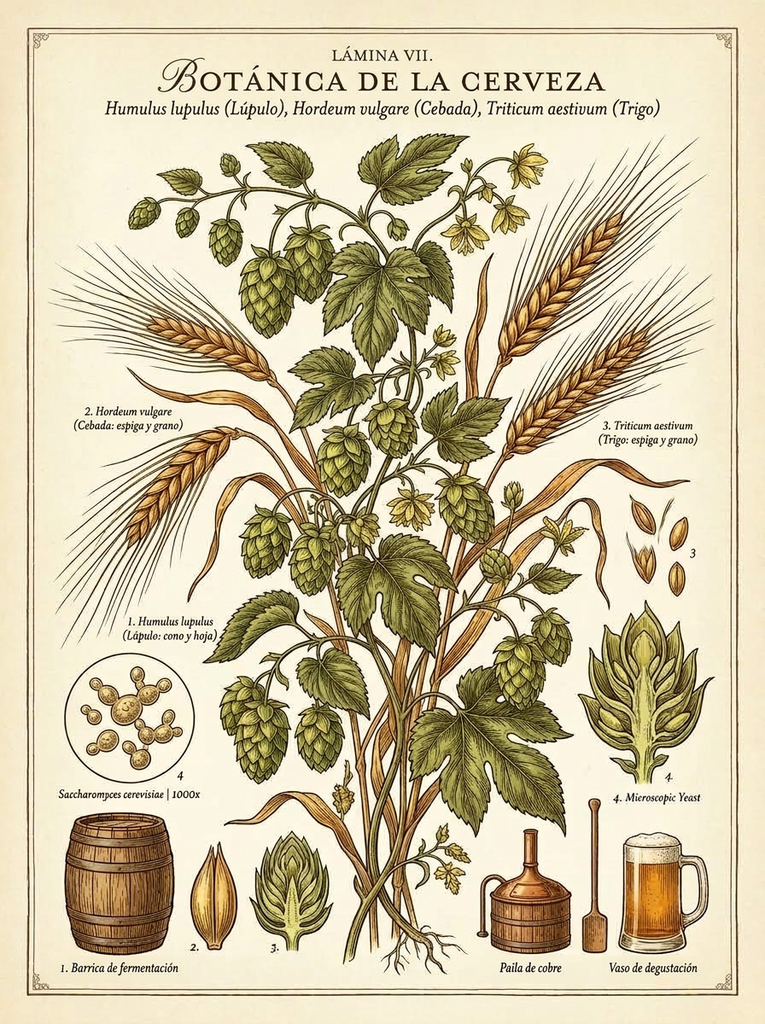

*Humulus lupulus*, *Hordeum vulgare*, *Triticum aestivum* & *Saccharomyces*

Guía Técnica & Sensorial

# Taxonomía de la Cerveza

### Familias de fermentación, cereales malteados y crudos, estilos y servicio

Fundamentos Microbiológicos

## Dinámica de Fermentación

La taxonomía cervecera se rige por la especie de levadura y su temperatura de trabajo.

### Familia Lager 7 °C – 13 °C

*Saccharomyces pastorianus* • Fermentación baja

Las levaduras actúan y sedimentan en el fondo del fermentador. Exige maduración prolongada en frío (*lagering*). Produce perfiles sensoriales limpios, secos y crujientes, destacando el grano malteado y los lúpulos nobles.

### Familia Ale 15 °C – 24 °C

*Saccharomyces cerevisiae* • Fermentación alta

Las levaduras ascienden y forman un manto en la superficie. Su metabolismo activo aporta riqueza organoléptica marcada por ésteres frutales (plátano, manzana) y fenoles especiados (clavo), con enorme versatilidad estilística.

### Espontánea y Mixta Ambiente / Barrica

*Brettanomyces*, *Lactobacillus* y microflora salvaje

El mosto se enfría en tinas abiertas (*koelschip*), capturando la microbiota autóctona. Madura durante meses o años en toneles de roble, desarrollando acidez láctica, notas terrosas, cuero y alta complejidad rústica.

| Familia | Levadura Principal | Temperatura | Maduración |
| --- | --- | --- | --- |
| **Lager** | *S. pastorianus* | 7–13 °C | Frío prolongado (*lagering*) |
| **Ale** | *S. cerevisiae* | 15–24 °C | Media (semanas) |
| **Espontánea** | Flora salvaje / *Brett.* | Ambiente | Años en madera |

Infografía Taxonómica

## Mapa de Estilos y Servicio

Subdivisiones estilísticas representativas y cristalería recomendada.

#### Lager Fermentación Baja

- **Pilsner / Pils:** Dorada, final seco, amargor floral y herbal.
- **Helles / Pale Lager:** Rubia pálida, cuerpo sedoso y balance maltoso.
- **Dunkel / Schwarzbier:** Tostada, notas a pan corteza y café suave.
- **Bock / Doppelbock:** Fuerte, rica en malta dulce y caramelo.

#### Ale Fermentación Alta

- **Pale Ale / APA:** Ámbar claro, lúpulo cítrico, herbal y resinoso.
- **IPA (India Pale Ale):** Carga masiva de lúpulo, amargor y notas frutales.
- **Trigo (Weiss / Witbier):** Trigo malteado y crudo; plátano y clavo. Trigo
- **Porter / Stout:** Malta torrefacta y cebada tostada; cacao y espresso.
- **Abadía (Dubbel / Tripel):** Complejas, cálidas, fruta madura y especias.

#### Espontánea & Sour Fermentación Salvaje

- **Lambic / Gueuze:** Acidez punzante, trigo crudo, perfil rústico añejo. Trigo Crudo
- **Fruit Lambic (Kriek):** Co-fermentada con cerezas o frambuesas en roble.
- **Gose / Berliner Weisse:** Trigo ácido, refrescante, láctica y salina. Trigo

#### Cristalería de Degustación

[figure not shown]

**Vaso Pilsner** Lager / Pils

[figure not shown]

**Pinta Nonic** Ale / IPA / Stout

[figure not shown]

**Vaso Weizen** Trigo / Weiss / Gose

[figure not shown]

**Copa Tulipa** Belgas / Sours / Lambic